# LIS 4317 Module 6

Patricia McGee

2/20/2022

## Data Description

For this assignment, I have pulled data from www.formula1.com. Specifically, I have pulled the 2020 and 2021 Driver Standings by Race for: Lewis Hamilton (Mercedes), Max Verstappen (Red Bull), Valtteri Bottas (Mercedes), Sergio Perez (Red Bull 2021, Racing Point 2020), and Alex Albon (Red Bull 2020).

Here, I plan to compare the average race points for Lewis Hamilton versus Max Verstappen year over year, as well as the average race points for Mercedes versus Red Bull year over year.

First, let’s read in the data which I have compiled in an Excel file called “LewisvsMax.xlsx”

```r
library(readxl)
library(dplyr)
```

```r
library(ggplot2)
library(scales)

RaceData <- read_excel("LewisvsMax.xlsx")
head(RaceData)
```

```
## # A tibble: 6 x 7
##    Year Driver      `GRAND PRIX` DATE                CAR   `RACE POSITION`   PTS
##   <dbl> <chr>       <chr>        <dttm>              <chr> <chr>           <dbl>
## 1  2021 Lewis Hami~ Bahrain      2021-03-28 00:00:00 MERC~ 1                  25
## 2  2021 Lewis Hami~ Emilia Roma~ 2021-04-18 00:00:00 MERC~ 2                  19
## 3  2021 Lewis Hami~ Portugal     2021-05-02 00:00:00 MERC~ 1                  25
## 4  2021 Lewis Hami~ Spain        2021-05-09 00:00:00 MERC~ 1                  25
## 5  2021 Lewis Hami~ Monaco       2021-05-23 00:00:00 MERC~ 7                   7
## 6  2021 Lewis Hami~ Azerbaijan   2021-06-06 00:00:00 MERC~ 15                  0
```

## Exploring and Manipulating the Data

Now that we have read in the data, let’s look at the summary of the data.

From here, we will want to determine the average points by driver by year, the average points by Car team by year, as well as the standard deviations for both values.

```r
summary(RaceData)
```

```
##       Year         Driver           GRAND PRIX
##  Min.   :2020   Length:170         Length:170
##  1st Qu.:2020   Class :character   Class :character
##  Median :2021   Mode  :character   Mode  :character
##  Mean   :2021
##  3rd Qu.:2021
##  Max.   :2021
##       DATE                         CAR            RACE POSITION
##  Min.   :2020-07-05 00:00:00   Length:170         Length:170
##  1st Qu.:2020-09-16 12:00:00   Class :character   Class :character
##  Median :2021-03-28 00:00:00   Mode  :character   Mode  :character
##  Mean   :2021-03-08 03:40:14
##  3rd Qu.:2021-08-29 00:00:00
##  Max.   :2021-12-12 00:00:00
##       PTS
##  Min.   : 0.00
##  1st Qu.: 4.50
##  Median :15.00
##  Mean   :13.02
##  3rd Qu.:19.00
##  Max.   :27.00
```

```r
RaceDataDriver <- RaceData %>%
  filter(Driver == "Lewis Hamilton" | Driver == "Max Verstappen") %>%
  group_by(Year, Driver) %>%
  mutate(avgDriverPts = mean(PTS),
         sdDriverPts = sd(PTS),
         DriverDev = (PTS - avgDriverPts)) %>%
  ungroup()

RaceDataDriver
```

```
## # A tibble: 77 x 10
##     Year Driver     `GRAND PRIX` DATE                CAR   `RACE POSITION`   PTS
##    <dbl> <chr>      <chr>        <dttm>              <chr> <chr>           <dbl>
##  1  2021 Lewis Ham~ Bahrain      2021-03-28 00:00:00 MERC~ 1                  25
##  2  2021 Lewis Ham~ Emilia Roma~ 2021-04-18 00:00:00 MERC~ 2                  19
##  3  2021 Lewis Ham~ Portugal     2021-05-02 00:00:00 MERC~ 1                  25
##  4  2021 Lewis Ham~ Spain        2021-05-09 00:00:00 MERC~ 1                  25
##  5  2021 Lewis Ham~ Monaco       2021-05-23 00:00:00 MERC~ 7                   7
##  6  2021 Lewis Ham~ Azerbaijan   2021-06-06 00:00:00 MERC~ 15                  0
##  7  2021 Lewis Ham~ France       2021-06-20 00:00:00 MERC~ 2                  18
##  8  2021 Lewis Ham~ Styria       2021-06-27 00:00:00 MERC~ 2                  19
##  9  2021 Lewis Ham~ Austria      2021-07-04 00:00:00 MERC~ 4                  12
## 10  2021 Lewis Ham~ Great Brita~ 2021-07-18 00:00:00 MERC~ 1                  27
## # ... with 67 more rows, and 3 more variables: avgDriverPts <dbl>,
## #   sdDriverPts <dbl>, DriverDev <dbl>
```

```r
RaceDataCar <- RaceData %>%
  filter(CAR != "RACING POINT BWT MERCEDES") %>%
  group_by(Year, CAR) %>%
  mutate(avgCarPts = mean(PTS),
          sdCarPts = sd(PTS),
         CarDev = (PTS - avgCarPts)) %>%
  ungroup()

RaceDataCar
```

```
## # A tibble: 155 x 10
##     Year Driver     `GRAND PRIX` DATE                CAR   `RACE POSITION`   PTS
##    <dbl> <chr>      <chr>        <dttm>              <chr> <chr>           <dbl>
##  1  2021 Lewis Ham~ Bahrain      2021-03-28 00:00:00 MERC~ 1                  25
##  2  2021 Lewis Ham~ Emilia Roma~ 2021-04-18 00:00:00 MERC~ 2                  19
##  3  2021 Lewis Ham~ Portugal     2021-05-02 00:00:00 MERC~ 1                  25
##  4  2021 Lewis Ham~ Spain        2021-05-09 00:00:00 MERC~ 1                  25
##  5  2021 Lewis Ham~ Monaco       2021-05-23 00:00:00 MERC~ 7                   7
##  6  2021 Lewis Ham~ Azerbaijan   2021-06-06 00:00:00 MERC~ 15                  0
##  7  2021 Lewis Ham~ France       2021-06-20 00:00:00 MERC~ 2                  18
##  8  2021 Lewis Ham~ Styria       2021-06-27 00:00:00 MERC~ 2                  19
##  9  2021 Lewis Ham~ Austria      2021-07-04 00:00:00 MERC~ 4                  12
## 10  2021 Lewis Ham~ Great Brita~ 2021-07-18 00:00:00 MERC~ 1                  27
## # ... with 145 more rows, and 3 more variables: avgCarPts <dbl>,
## #   sdCarPts <dbl>, CarDev <dbl>
```

## Plotting the Data by Driver

Our first plot here, plots the deviation from the average points for the two drivers, Lewis Hamilton and Max Verstappen, for all races 2020 and 2021.

The second plot directly compares their race points.

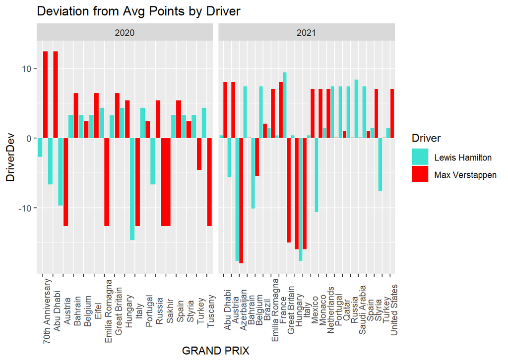

```r
RaceDataDriver %>%
  ggplot(aes(x = `GRAND PRIX`, y = DriverDev, fill = Driver))+
  geom_bar(stat = "identity", position = position_dodge(width = 1))+
  theme(axis.text.x = element_text(angle = 90))+
  scale_fill_manual(values = c("turquoise","red"))+
  facet_wrap(vars(Year), scales = "free_x")+
  labs(title = "Deviation from Avg Points by Driver")
```

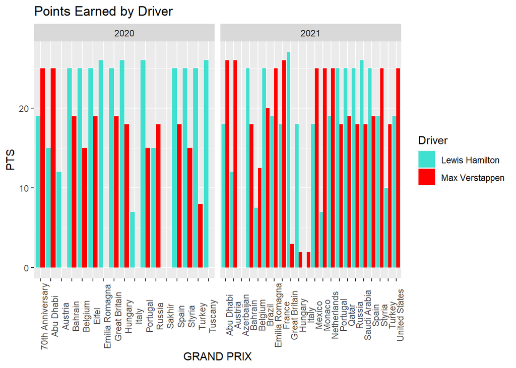

```r
RaceDataDriver %>%
  ggplot(aes(x = `GRAND PRIX`, y = PTS, fill = Driver))+
  geom_bar(stat = "identity", position = position_dodge())+
  theme(axis.text.x = element_text(angle = 90))+
  scale_fill_manual(values = c("turquoise","red"))+
  facet_wrap(vars(Year), scales = "free_x")+
  labs(title = "Points Earned by Driver")
```

## Plotting the Data by Car Constructor

Here, we have plotted the deviation from average points by Car Constructor, comparing Mercedes to Red Bull.

The second plot directly compares the points earned each race.

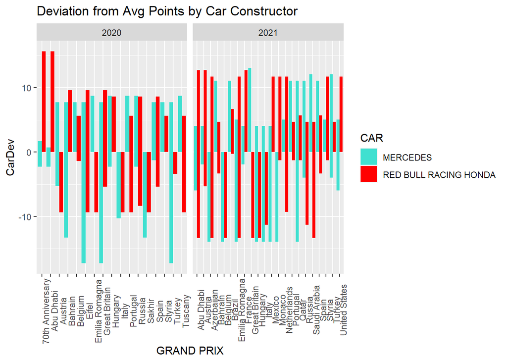

```r
RaceDataCar %>%
  ggplot(aes(x = `GRAND PRIX`, y = CarDev, fill = CAR))+
  geom_bar(stat = "identity", position = position_dodge())+
  theme(axis.text.x = element_text(angle = 90))+
  scale_fill_manual(values = c("turquoise","red"))+
  facet_wrap(vars(Year), scales = "free_x")+
  labs(title = "Deviation from Avg Points by Car Constructor")
```

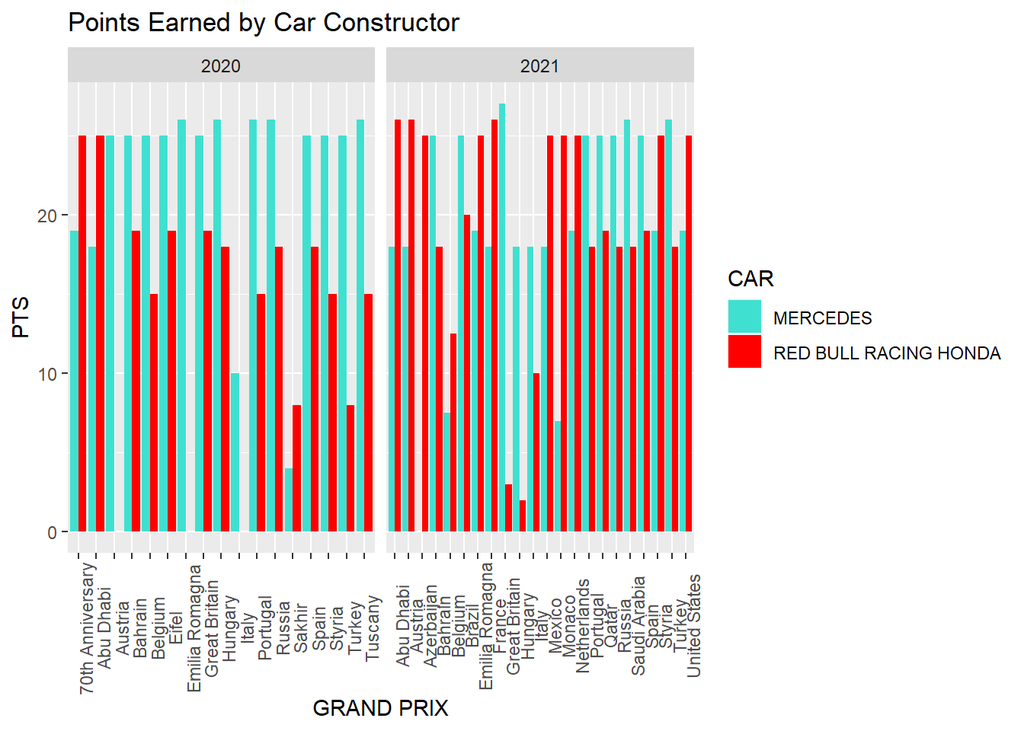

```r
RaceDataCar %>%
  ggplot(aes(x = `GRAND PRIX`, y = PTS, fill = CAR))+
  geom_bar(stat = "identity", position = position_dodge())+
  theme(axis.text.x = element_text(angle = 90))+
  scale_fill_manual(values = c("turquoise","red"))+
  facet_wrap(vars(Year), scales = "free_x")+
  labs(title = "Points Earned by Car Constructor")
```